# Sentiment Analysis (By Sentences)

Unstructured Data Analytics (UDA)

```r
#load packages
library(dplyr)
library(stringr)
library(tidytext)
library(textdata)
library(ggplot2)
```

## Start simple

Let’s look at a short example. First let’s do regular bag of words sentiment, and aggregate by sentence.

```r
corpus <- tibble(sentences = c("I like chocolate",
                                  "I really like chocolate",
                                  "I don't like chocolate",
                                  "I hardly like chocolate",
                                  "I love vanilla, but I don't like chocolate"),
                    sentence_id = 1:5)

#tokenize, add sentiment scoring, aggregate
corpus %>%
  unnest_tokens(output = word, input = sentences, token = "words") %>%
  inner_join(get_sentiments("afinn"), by = "word") %>%
  group_by(sentence_id) %>%
  summarize(afinn_total = sum(value, na.rm = T),
            afinn_avg = mean(value, na.rm = T)) %>%
  #add the original sentences back in so we can compare
  inner_join(corpus, by = "sentence_id")
```

| sentence_id | afinn_total | afinn_avg | sentences |
| --- | --- | --- | --- |
| 1 | 2 | 2.0 | I like chocolate |
| 2 | 2 | 2.0 | I really like chocolate |
| 3 | 2 | 2.0 | I don't like chocolate |
| 4 | 2 | 2.0 | I hardly like chocolate |
| 5 | 5 | 2.5 | I love vanilla, but I don't like chocolate |

**Question:** does this match how you want to understand the sentences?

Let’s try a sentence-level breakout

```r
library(sentimentr) #you may need to install this package
corpus %>%
  get_sentences() %>%
  sentiment() %>%
  #rearrange columns for better viewing
  select(element_id, sentences, sentiment, word_count, everything())
```

|  | element_id | sentences | sentiment | word_count | sentence_id |
| --- | --- | --- | --- | --- | --- |
| 1 | 1 | I like chocolate | 0.6350853 | 3 | 1 |
| 2 | 2 | I really like chocolate | 0.9900000 | 4 | 1 |
| 3 | 3 | I don't like chocolate | -0.5500000 | 4 | 1 |
| 4 | 4 | I hardly like chocolate | 0.1100000 | 4 | 1 |
| 5 | 5 | I love vanilla, but I don't like chocolate | -0.6098796 | 8 | 1 |

**Question**: do you like this better?

The sentiment function automatically uses the lexicon::hash_sentiment_jockers_rinkers to assign polarity, and the valence_shifter lexicon::hash_valence_shifters to handle valence.

You can adjust which lexicons/shifters are used and how much they affect the output by changing the arguments for the function.

Run `?sentiment` to open the help page. The *Usage* section shows all of the arguments with any default values. The *Arguments* section provides more details. The *Value* section explains what is returned and the *Examples* section at the end shows sample code you can run and experiment with.

Try running the sentiment again, but adjust something and compare to what you got above.

```r
corpus %>%
  get_sentences() %>%
  sentiment() %>%  #add some arguments within the sentiment() call to change the defaults
  select(element_id, sentences, sentiment, word_count, everything())
```

|  | element_id | sentences | sentiment | word_count | sentence_id |
| --- | --- | --- | --- | --- | --- |
| 1 | 1 | I like chocolate | 0.6350853 | 3 | 1 |
| 2 | 2 | I really like chocolate | 0.9900000 | 4 | 1 |
| 3 | 3 | I don't like chocolate | -0.5500000 | 4 | 1 |
| 4 | 4 | I hardly like chocolate | 0.1100000 | 4 | 1 |
| 5 | 5 | I love vanilla, but I don't like chocolate | -0.6098796 | 8 | 1 |

## Small scale to bigger scale: sentence-level or chapter-level sentiment in Alice

The first challenge is getting the text to be analyzable by sentence.

```r
#########
# basic setup
#########

#load package
library(gutenbergr)

#download, add chapters, remove title matter,
alice <- gutenberg_download(11) %>%
  mutate(chapter = cumsum(str_detect(text, pattern = "^CHAPTER [IVX]+\\.*$"))) %>%
  filter(chapter > 0) %>%
  select(-gutenberg_id) #this is just in the way; we don't need it for 1 book


#########
#prep for sentence analysis
########

#note: you can group_by and mutate to create new fields on a group-by-group basis
#it will add values to each row, unless you summarize in some way
#we aren't summarizing here
alice_long <- alice %>%
  group_by(chapter) %>%
  mutate(long_text = paste(text, collapse = " ")) %>%
  ungroup() %>%
  select(long_text, chapter) %>%
  distinct()

#check it
alice_long[1,]
```

| long_text | chapter |
| --- | --- |
| CHAPTER I. Down the Rabbit-Hole Alice was beginning to get very tired of sitting by her sister on the bank, and of having nothing to do: once or twice she had peeped into the book her sister was readi… | 1 |

Can you break this into sentences, number the sentences with a sentence_id, and tokenize the sentences by word, and create an AFINN sentiment score sentence-by-sentence or chapter-by-chapter? Fill in the ?? with the right code or column names

```r
#break it into sentences
alice_sentences <-alice_long %>%
  #the input column has to be a valid column name from your starting data
  unnest_tokens(output = sentences, input = long_text, token = "sentences") %>%
  mutate(sentence_id = row_number())

#break sentences into words
alice_words <- alice_sentences %>%
  unnest_tokens(output = words, input = sentences, token = "words")

#add sentiments
alice_words_sentiments <- alice_words %>%
  #the join needs keys: if your key columns have different names, join them like this:
  inner_join(get_sentiments("afinn"), by = c("words" = "word"))

#aggregate scores
alice_summarized <- alice_words_sentiments %>%
  #you could also group by sentence_id
  #or you could create a new grouping level, like break each chapter in 4 groups of sentences
  group_by(chapter) %>%
  summarize(total = sum(value, na.rm = T),
            avg = mean(value, na.rm = T)) %>%
  ungroup()

#take a look
alice_summarized[1:5,]
```

| chapter | total | avg |
| --- | --- | --- |
| 1 | 40 | 0.36036036 |
| 2 | -3 | -0.02290076 |
| 3 | 9 | 0.10227273 |
| 4 | 42 | 0.31818182 |
| 5 | -6 | -0.07317073 |

Let’s graph it too – add your column names in place of ??

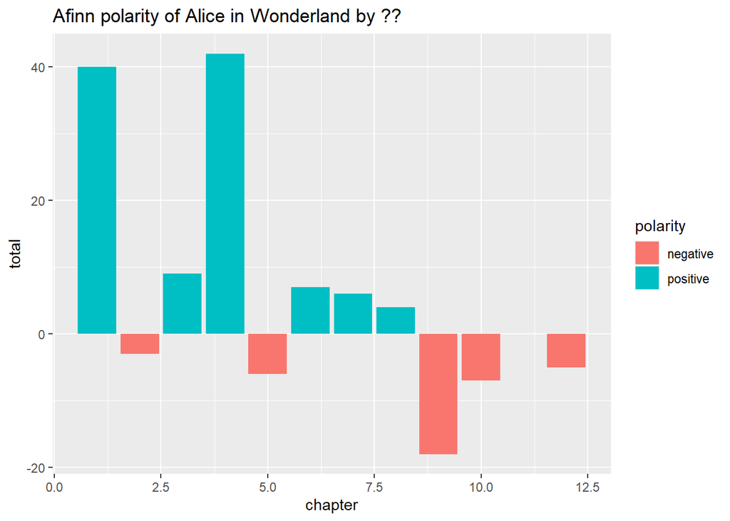

```r
#prep the data again
#set up a polarity flag so we can use it for color
alice_summarized %>%
  #add a polarity flag
  mutate(polarity = ifelse(total > 0, "positive", "negative")) %>%  #WHOOPS! We need to add a pipe!

  #feed it into a basic bar graph
  ggplot(aes(x = chapter, y = total, fill = polarity)) +
  geom_bar(stat = "identity") +
  ggtitle("Afinn polarity of Alice in Wonderland by ??")
```

*Question* What do you notice about this? Does it line up at all with the common words you analyzed previously or the plot summary you read?

**Question:** If you break it out by chapter vs sentences, do you get a different impression of the book?

We could adjust our results by trying different sentiment lexicons at the chapter vs sentence level.

But let’s see how valence affects our answers

## Alice with sentimentr

Start again with the chapter-in-a-cell text, and see how this tokenizes

```r
library(sentimentr)
alice_sentences_new <- get_sentences(alice_long)

#check it
alice_sentences_new[1:10,]
```

| long_text | chapter | element_id | sentence_id |
| --- | --- | --- | --- |
| CHAPTER I. | 1 | 1 | 1 |
| Down the Rabbit-Hole Alice was beginning to get very tired of sitting by her sister on the bank, and of having nothing to do: once or twice she had peeped into the book her sister was reading, but it … | 1 | 1 | 2 |
| There was nothing so _very_ remarkable in that; nor did Alice think it so _very_ much out of the way to hear the Rabbit say to itself, “Oh dear! | 1 | 1 | 3 |
| Oh dear! | 1 | 1 | 4 |
| I shall be late!” (when she thought it over afterwards, it occurred to her that she ought to have wondered at this, but at the time it all seemed quite natural); but when the Rabbit actually _took a w… | 1 | 1 | 5 |
| In another moment down went Alice after it, never once considering how in the world she was to get out again. | 1 | 1 | 6 |
| The rabbit-hole went straight on like a tunnel for some way, and then dipped suddenly down, so suddenly that Alice had not a moment to think about stopping herself before she found herself falling dow… | 1 | 1 | 7 |
| Either the well was very deep, or she fell very slowly, for she had plenty of time as she went down to look about her and to wonder what was going to happen next. | 1 | 1 | 8 |
| First, she tried to look down and make out what she was coming to, but it was too dark to see anything; then she looked at the sides of the well, and noticed that they were filled with cupboards and b… | 1 | 1 | 9 |
| She took down a jar from one of the shelves as she passed; it was labelled “ORANGE MARMALADE”, but to her great disappointment it was empty: she did not like to drop the jar for fear of killing somebo… | 1 | 1 | 10 |

Now let’s add some sentiment and aggregate

```r
#let's add a sentiment scores for some level: chapters or sentences
#method 1:
alice_sentences_new %>%
  sentiment() %>%
  group_by(chapter) %>%
  summarize(avg = mean(sentiment, na.rm = T))
```

| chapter | avg |
| --- | --- |
| 1 | 0.0706871428 |
| 2 | -0.0270367743 |
| 3 | -0.0373037711 |
| 4 | 0.0237805818 |
| 5 | 0.0061324523 |
| 6 | 0.0003120604 |
| 7 | 0.0559144493 |
| 8 | -0.0063434680 |
| 9 | 0.0232249385 |
| 10 | 0.0204435211 |

[output cut: 2 more lines]

```r
#method 2:
alice_sentences_new %>%
  sentiment_by(by = "chapter")
```

|  | chapter | word_count | sd | ave_sentiment |
| --- | --- | --- | --- | --- |
| 1 | 1 | 2195 | 0.2539916 | 0.079465670 |
| 2 | 2 | 2188 | 0.2707884 | -0.033741133 |
| 3 | 3 | 1741 | 0.3124348 | -0.042423752 |
| 4 | 4 | 2740 | 0.2209729 | 0.030675504 |
| 5 | 5 | 2245 | 0.2352319 | 0.008177371 |
| 6 | 6 | 2672 | 0.2990861 | 0.000357607 |
| 7 | 7 | 2387 | 0.2710962 | 0.069931181 |
| 8 | 8 | 2561 | 0.2044590 | -0.007202647 |
| 9 | 9 | 2366 | 0.2457043 | 0.026083046 |
| 10 | 10 | 2103 | 0.3012489 | 0.025850084 |

[output cut: 2 more lines]

**Question:** do these end up the same or with a similar message? To see the options for sentiment_by, look at the help page `?sentiment_by`

**Question:** what preprocessing is done by the get_sentences function?

**Question:** Does the valence and lexicon in sentimentr give you a result that works better than straight bag-of-words methods?

### FYI

SentimentAnalysis is an even newer package that has been released

We aren’t going to spend time on it together, but you can explore it through [CRAN](https://cran.r-project.org/web/packages/SentimentAnalysis/index.html). The vignette page is a good place to start.

If you want to install and mess around with it, start with our basic corpus sentences

```r
#load the package (you probably have to install it)
library(SentimentAnalysis)

# SentimentAnalysis likes to work with vectors, not data frames
# It can also accept a DTM or a topic modeling object
# For today, we can convert a column into a string vector
corpus_vector <- corpus %>% pull(sentences)
sentiment <- analyzeSentiment(corpus_vector)

#what do we get out?
sentiment
```

| WordCount | SentimentGI | NegativityGI | PositivityGI | SentimentHE | NegativityHE | PositivityHE | SentimentLM | NegativityLM | PositivityLM | RatioUncertaintyLM | SentimentQDAP | NegativityQDAP | PositivityQDAP |
| --- | --- | --- | --- | --- | --- | --- | --- | --- | --- | --- | --- | --- | --- |
| 2 | 0.5000000 | 0.0000000 | 0.5000000 | 0 | 0 | 0 | 0 | 0 | 0 | 0 | 0.5000000 | 0.0000000 | 0.5000000 |
| 3 | 0.3333333 | 0.0000000 | 0.3333333 | 0 | 0 | 0 | 0 | 0 | 0 | 0 | 0.3333333 | 0.0000000 | 0.3333333 |
| 3 | 0.3333333 | 0.0000000 | 0.3333333 | 0 | 0 | 0 | 0 | 0 | 0 | 0 | 0.3333333 | 0.0000000 | 0.3333333 |
| 3 | 0.0000000 | 0.3333333 | 0.3333333 | 0 | 0 | 0 | 0 | 0 | 0 | 0 | 0.0000000 | 0.3333333 | 0.3333333 |
| 5 | 0.4000000 | 0.0000000 | 0.4000000 | 0 | 0 | 0 | 0 | 0 | 0 | 0 | 0.4000000 | 0.0000000 | 0.4000000 |

What were the sentences?

```r
corpus
```

| sentences | sentence_id |
| --- | --- |
| I like chocolate | 1 |
| I really like chocolate | 2 |
| I don't like chocolate | 3 |
| I hardly like chocolate | 4 |
| I love vanilla, but I don't like chocolate | 5 |

Whoa, that’s a lot of output. What does it mean? What can we do with it? Let’s check the documentation again.

**Question:** Does this package seem useful? What might it be helpful for compared to the other two packages?